# 多變量預測:CPI預測

組員:1106201張唯潁、1115008楊子翧

## 目錄

- 動機與目的
- 資料說明
- 1.資料前處理(平穩化、因果關係、相關性檢驗)
- 2.VAR-Modeling
- 3.Auto-ARIMA-Model
- 4.Prophet
- 5.Machine Learning - Linear and Nonlinear Regression Models (機器學習 - 線性和非線性回歸模型)
- 6.Conclusion

## 動機與目的

根據近期的新聞發現一件事，當CPI下降時，股市可能會上漲。  
由於s&p500是領先指標，CPI是落後指標，因此CPI受到股價影響是有可能的。

CPI是一種經濟的結果和現象，它不會直接影響股市，但是CPI會影響政策制定，而政策會影響股市。例如央行是否升息降息、是否調整存款準備金比率等。  
換句話說，CPI與股市(以標普500指數為例(S&P500))沒有直接關係，但 CPI 的變化與標普500指數的表現可能存在相關性。一般而言，當 CPI 上升時，可以表明經濟存在通膨。高通膨會導致消費者支出和投資減少，進而導致股價下跌。此外，當美聯儲加息以對抗通貨膨脹時，可能會導致股價下跌。另一方面，當CPI穩定或下降時，可以表明經濟中很少或沒有通脹。這對股價來說可能是一個積極信號，因為低通脹可以為公司帶來更有利的經濟環境，從而提高收益並使股票對投資者更具吸引力。

本益比是一種估值指標，顯示投資者願意為公司的收益支付多少。  
投資者願意在通貨膨脹率高時為一定水平的收益支付更少的費用，而在通貨膨脹率低（並且預計會保持這種水平）時為一定水平的收益支付更多費用。  
因此本益比與CPI也是息息相關的。

根據reference文章表示，經濟理論表明，通貨膨脹率隨著失業率下降而上升。因為根據菲利普斯曲線，較低的失業率意味著人們會花更多的錢，從而對價格造成更大的壓力，而通膨與失業率也可能呈正向關係(政策)。通膨與失業率可以說是互相影響，較高的失業率等同於較低的通貨膨脹率。當更多的人在工作時，他們就有能力消費，從而導致需求增加。價格（通貨膨脹）很快就會隨之而來。當失業率上升時，情況正好相反。  
因此也可以說是CPI影響失業率，而失業率又影響CPI。

因此本project目的是在研究當代表的股價、本益比與失業率的漲跌，是否會使CPI會有連帶的漲與跌、看能否預測CPI的時間序列。

返回目錄

## 資料說明

所有資料時間為2013-01-01到2022-12-01  
皆為以月為單位的資料

#### ./data/CPIAUCSL_PC1_SP500_Unrate.xlsx

1. CPIAUCSL_PC1: CPI(Consumer Price Index)，消費者物價指數，美國所有城市商品的平均

Percent Change from Year Ago, Monthly, Seasonally Adjusted

2. SP500: S&P 500，美國 500 家最大上市公司業績的股票市場指數

Index, Monthly, Not Seasonally Adjusted

3. UNRATE: 失業率

Percent, Monthly, Seasonally Adjusted

#### ./data/MULTPL-SP500_PE_RATIO_MONTH_2013.csv

4. SP500_PE: price-earnings ratio(PE ratio)，是本益比，也可稱為市盈率，是衡量一家公司價值的方法。本益比可按公司每股市價除以每股收益計算得出。

Monthly

## Reference:

1. [Inflation and Unemployment](https://www.investopedia.com/ask/answers/040715/what-happens-when-inflation-and-unemployment-are-positively-correlated.asp)
2. [P/E Ratios and Inflation](https://www.investopedia.com/ask/answers/123.asp)
3. [CPI vs S&P500 P/E Ratio](https://en.macromicro.me/collections/34/us-stock-relative/49738/us-sp500-pe-cpi-yoy)

返回目錄

## 1.資料前處理(平穩化、因果關係、相關性檢驗)

```python
# 定義函數以便執行肩並肩的列印
def side_by_side(*objs, **kwds):
    from pandas.io.formats.printing import adjoin
    space = kwds.get('space', 4)
    reprs = [repr(obj).split('\n') for obj in objs]
    print (adjoin(space, *reprs))
    print()
    return
```

```python
import pandas as pd
dataDF = pd.read_excel('data/CPIAUCSL_PC1_SP500_Unrate.xlsx', skiprows = 12,
                       parse_dates=['observation_date'])

dataDF.rename(columns={'observation_date':'date'}, inplace=True)

dataDF.set_index('date', inplace=True)
pd.concat([dataDF.head(3), dataDF.tail(3)])
```

| date | CPIAUCSL_PC1 | SP500 | UNRATE |
| --- | --- | --- | --- |
| 2013-01-01 | 1.68406 | 1498.11 | 8.0 |
| 2013-02-01 | 2.01814 | 1514.68 | 7.7 |
| 2013-03-01 | 1.51875 | 1569.19 | 7.5 |
| 2022-10-01 | 7.76312 | 3871.98 | 3.7 |
| 2022-11-01 | 7.11788 | 4080.11 | 3.7 |
| 2022-12-01 | NaN | 3839.50 | NaN |

```python
sp500_PE = pd.read_csv('data/MULTPL-SP500_PE_RATIO_MONTH_2013.csv',  parse_dates=['Date'])

sp500_PE = sp500_PE.iloc[::-1]

dataDF['SP500_PE'] = sp500_PE['Value'].to_list()
pd.concat([dataDF.head(3), dataDF.tail(3)])
```

| date | CPIAUCSL_PC1 | SP500 | UNRATE | SP500_PE |
| --- | --- | --- | --- | --- |
| 2013-01-01 | 1.68406 | 1498.11 | 8.0 | 17.03 |
| 2013-02-01 | 2.01814 | 1514.68 | 7.7 | 17.32 |
| 2013-03-01 | 1.51875 | 1569.19 | 7.5 | 17.68 |
| 2022-10-01 | 7.76312 | 3871.98 | 3.7 | 19.38 |
| 2022-11-01 | 7.11788 | 4080.11 | 3.7 | 20.38 |
| 2022-12-01 | NaN | 3839.50 | NaN | 21.13 |

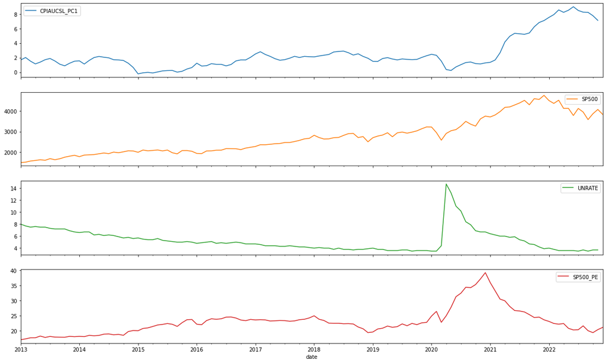

```python
import matplotlib.pyplot as plt
dataDF.plot(subplots=True, figsize=(20,12))
plt.show()
```

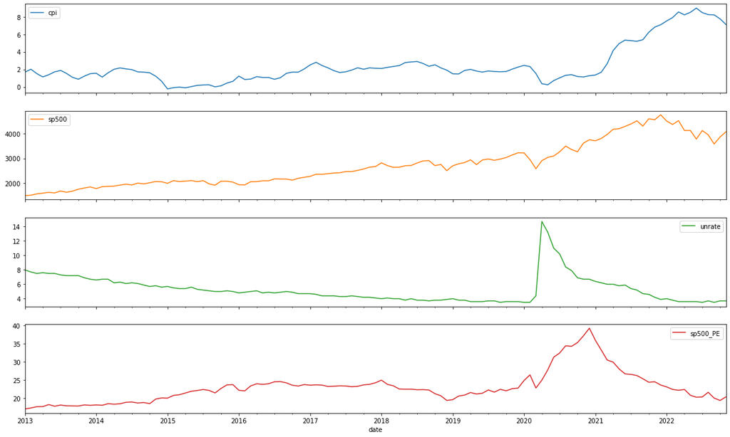

```python
import matplotlib.pyplot as plt
dataDF.dropna(inplace=True)
df2 = dataDF.dropna().copy()
df2.columns = ['cpi', 'sp500', 'unrate', 'sp500_PE']
df2.plot(subplots=True, figsize=(20,12))
plt.show()
```

#### sp500和cpi之間存在某種正比關係，隨著sp500的增加，cpi也跟著上升。

#### unrate則是和sp500_PE之間在2020年後存在某種正比關係。

### Stationarity Test

```python
from statsmodels.tsa.stattools import adfuller
def stationary_TS(ts):
    name = ts.name
    print(f"{ts.name} p-value: {adfuller(ts)[1]}")
    if adfuller(ts)[1] > 0.05:
        print(f'{ts.name} p-value > 0.05，我們不能拒絕原假設(也就是說我們有一個非平穩的數據集)。')
    else:
        print(f'{ts.name} p-value < 0.05，我們拒絕原假設(也就是說我們有一個平穩的數據集)。')
```

```python
for i in dataDF:
    stationary_TS(dataDF[i])
```

```
CPIAUCSL_PC1 p-value: 0.6201640281022444
CPIAUCSL_PC1 p-value > 0.05，我們不能拒絕原假設(也就是說我們有一個非平穩的數據集)。
SP500 p-value: 0.8138695256195796
SP500 p-value > 0.05，我們不能拒絕原假設(也就是說我們有一個非平穩的數據集)。
UNRATE p-value: 0.019433463666831956
UNRATE p-value < 0.05，我們拒絕原假設(也就是說我們有一個平穩的數據集)。
SP500_PE p-value: 0.1152030602526064
SP500_PE p-value > 0.05，我們不能拒絕原假設(也就是說我們有一個非平穩的數據集)。
```

#### 大多數都是非平穩，因此畫出ACF圖來看如何調整成平穩的

### ACF and PACF Plots

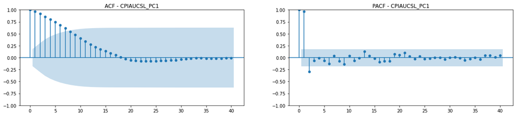

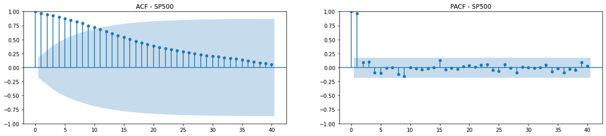

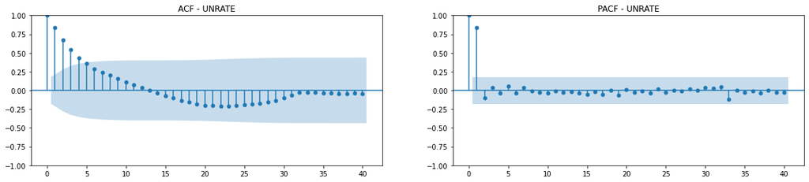

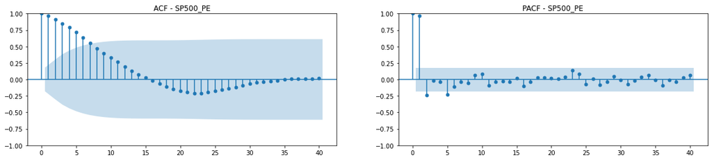

```python
from statsmodels.graphics.tsaplots import plot_acf, plot_pacf
for col in dataDF.columns:
    fig, ax = plt.subplots(1,2, figsize=(20,4))
    plot_acf(dataDF[col], zero=True, lags=40, ax=ax[0], title=f'ACF - {col}')
    plot_pacf(dataDF[col], zero=True, method='ywm', lags=40, ax=ax[1], title=f'PACF - {col}')
    plt.show()
```

#### 例如'CPIAUCSL_PC1'第9根開始在陰影下，因此選擇從diff(8)開始測試是否變平穩

```python
stationary_TS(dataDF['CPIAUCSL_PC1'].diff(8).dropna())
```

```
CPIAUCSL_PC1 p-value: 0.039214137505328914
CPIAUCSL_PC1 p-value < 0.05，我們拒絕原假設(也就是說我們有一個平穩的數據集)。
```

```python
stationary_TS(dataDF['SP500'].diff(9).dropna())
```

```
SP500 p-value: 0.020174316611766344
SP500 p-value < 0.05，我們拒絕原假設(也就是說我們有一個平穩的數據集)。
```

```python
stationary_TS(dataDF['UNRATE'].diff(4).dropna())
```

```
UNRATE p-value: 0.015703341489008225
UNRATE p-value < 0.05，我們拒絕原假設(也就是說我們有一個平穩的數據集)。
```

```python
stationary_TS(dataDF['SP500_PE'].diff(6).dropna())
```

```
SP500_PE p-value: 0.04161225041101995
SP500_PE p-value < 0.05，我們拒絕原假設(也就是說我們有一個平穩的數據集)。
```

```python
diffCPI = dataDF['CPIAUCSL_PC1'].diff(8).dropna()
diffSP500 = dataDF['SP500'].diff(9).dropna()
diffUNRATE = dataDF['UNRATE'].diff(4).dropna()
diffSP500_PE = dataDF['SP500_PE'].diff(6).dropna()
```

```python
diffDF = pd.concat([diffCPI, diffSP500, diffUNRATE, diffSP500_PE], join='inner', axis=1)
pd.concat([diffDF.head(3), diffDF.tail(3)])
```

| date | CPIAUCSL_PC1 | SP500 | UNRATE | SP500_PE |
| --- | --- | --- | --- | --- |
| 2013-10-01 | -1.14134 | 258.43 | -0.3 | 0.17 |
| 2013-11-01 | -0.28588 | 291.13 | -0.4 | -0.10 |
| 2013-12-01 | 0.37403 | 279.17 | -0.5 | 0.24 |
| 2022-09-01 | 0.69648 | -1180.56 | -0.1 | -2.16 |
| 2022-10-01 | -0.14890 | -643.57 | 0.1 | -3.02 |
| 2022-11-01 | -1.43971 | -293.83 | 0.2 | -0.43 |

```python
for i in diffDF:
    stationary_TS(diffDF[i])
```

```
CPIAUCSL_PC1 p-value: 0.03038164429337672
CPIAUCSL_PC1 p-value < 0.05，我們拒絕原假設(也就是說我們有一個平穩的數據集)。
SP500 p-value: 0.020174316611766344
SP500 p-value < 0.05，我們拒絕原假設(也就是說我們有一個平穩的數據集)。
UNRATE p-value: 0.01959946495191359
UNRATE p-value < 0.05，我們拒絕原假設(也就是說我們有一個平穩的數據集)。
SP500_PE p-value: 0.04559135206732243
SP500_PE p-value < 0.05，我們拒絕原假設(也就是說我們有一個平穩的數據集)。
```

#### 所有變數都變平穩的，後續皆以此份資料來做分析、預測

```python
target = diffDF['CPIAUCSL_PC1']
featureData = diffDF[['SP500', 'UNRATE', 'SP500_PE']]
```

### Causality Test (因果關係檢驗)

```python
# df = diffDF.copy()
# df.columns=['cpi', 'sp500', 'unrate', 'sp500_pe']
```

```python
from statsmodels.tsa.stattools import grangercausalitytests
granger1 = grangercausalitytests(diffDF[['CPIAUCSL_PC1', 'SP500']].dropna(), maxlag=12, verbose=False)
granger2 = grangercausalitytests(diffDF[['CPIAUCSL_PC1', 'UNRATE']].dropna(), maxlag=12, verbose=False)
granger3 = grangercausalitytests(diffDF[['CPIAUCSL_PC1', 'SP500_PE']].dropna(), maxlag=12, verbose=False)

print('SP500    ',[round(granger1[i+1][0]['ssr_chi2test'][1],4) for i in range(12)])
print('UNRATE   ',[round(granger2[i+1][0]['ssr_chi2test'][1],4) for i in range(12)])
print('SP500_PE ',[round(granger3[i+1][0]['ssr_chi2test'][1],4) for i in range(12)])
```

```
SP500     [0.0, 0.0081, 0.0002, 0.0009, 0.0009, 0.0027, 0.0057, 0.0033, 0.0001, 0.0006, 0.0003, 0.0001]
UNRATE    [0.5066, 0.4363, 0.2503, 0.3264, 0.5567, 0.5835, 0.6689, 0.5808, 0.7497, 0.705, 0.2038, 0.2886]
SP500_PE  [0.445, 0.9407, 0.5648, 0.3042, 0.2527, 0.3211, 0.0021, 0.0022, 0.0001, 0.0, 0.0, 0.0]
```

#### 'SP500'->'CPIAUCSL_PC1'

所有p值都小於0.05，這表明我們可以拒絕原假設。代表sp500的影響在統計上是顯著的。我們可以說sp500確實對cpi有Granger cause。

#### 'UNRATE'->'CPIAUCSL_PC1'

沒有任何p值小於0.05，這表明接受拒絕原假設。代表UNRATE的影響在統計上並非顯著的，UNRATE對cpi沒有Granger cause。

#### 'SP500_PE'->'CPIAUCSL_PC1'

第七個p開始小於0.05，這表明我們應該可以拒絕原假設。代表SP500_PE的影響在統計上可能是顯著的。我們可以說SP500_PE可能對cpi有Granger cause。

### Cointegration Test

(如果X的變化先於Y的變化，那麼X可能是Y的原因。)

```python
from statsmodels.tsa.stattools import coint

def coint_func(x,y):
    coint_pval = coint(x, y)[1]
    print("p-value: ", coint_pval)
    if coint_pval < 0.05:
        print("They are cointegrated (協整的)")
    else:
        print("They are not cointegrated (不協整的)")
```

```python
coint_func(diffDF['SP500'], diffDF['CPIAUCSL_PC1'])
coint_func(diffDF['UNRATE'], diffDF['CPIAUCSL_PC1'])
coint_func(diffDF['SP500_PE'], diffDF['CPIAUCSL_PC1'])
```

```
p-value:  0.04746882072731097
They are cointegrated (協整的)
p-value:  0.02686248504496904
They are cointegrated (協整的)
p-value:  0.15466776607683352
They are not cointegrated (不協整的)
```

#### SP500、UNRATE可能是影響cpi的原因，而SP500_PE則可能不是

### F_Regression

線性回歸的F-test是檢驗多元線性回歸模型中的任何自變量(特徵)與目標變量是否有顯著統計關係。

```python
from sklearn.feature_selection import f_regression

F_value, P_value = f_regression(featureData, target)
lrStatisticsDF = pd.DataFrame(data = [F_value, P_value], columns= featureData.columns,
                              index=["F_value", "P_value"]).sort_values(by='P_value', axis=1, ascending=True).T
lrStatisticsDF
```

|  | F_value | P_value |
| --- | --- | --- |
| SP500_PE | 84.298452 | 3.377301e-15 |
| SP500 | 15.395890 | 1.536411e-04 |
| UNRATE | 4.575274 | 3.468959e-02 |

```python
# 顯示那些特徵變數是與目標變數'cpi'是無關的
lrStatisticsDF[lrStatisticsDF.P_value >= 0.05]
```

|  | F_value | P_value |
| --- | --- | --- |

#### 沒有變數與目標變數'cpi'是無關的

返回目錄

### 2.VAR Modeling

```python
from statsmodels.tsa.api import VAR
train = diffDF[:90]
test = diffDF[90:]
print(f'Train: {len(train)}, Test: {len(test)}')
```

```
Train: 90, Test: 20
```

### Find VAR order p, The VAR will determine the best p values that minimize each of the four information criteria scores: AIC, BIC, FPE, and HQIC.

```python
model = VAR(endog=train, freq='MS')
result = model.select_order(maxlags=10)
result.summary()
```

VAR Order Selection (* highlights the minimums)

|  | AIC | BIC | FPE | HQIC |
| --- | --- | --- | --- | --- |
| 0 | 14.28 | 14.40 | 1.597e+06 | 14.33 |
| 1 | 9.917 | 10.51 | 2.029e+04 | 10.16 |
| 2 | 9.259 | 10.33* | 1.054e+04 | 9.689 |
| 3 | 9.335 | 10.88 | 1.145e+04 | 9.955 |
| 4 | 8.866 | 10.89 | 7277. | 9.678 |
| 5 | 8.222 | 10.72 | 3915. | 9.225 |
| 6 | 8.020 | 11.00 | 3317. | 9.214 |
| 7 | 7.686 | 11.14 | 2501. | 9.071 |
| 8 | 7.874 | 11.80 | 3237. | 9.449 |
| 9 | 7.216 | 11.62 | 1845. | 8.983 |
| 10 | 6.351* | 11.23 | 880.4* | 8.309* |

```python
result.selected_orders
```

```
{'aic': 10, 'bic': 2, 'hqic': 10, 'fpe': 10}
```

### Use the AIC score

#### AIC為10，maxlags也設10

```python
results = model.fit(maxlags=10, ic='aic')
```

```python
results.summary()
```

```
  Summary of Regression Results
==================================
Model:                         VAR
Method:                        OLS
Date:           Sat, 14, Jan, 2023
Time:                     19:33:19
--------------------------------------------------------------------
No. of Equations:         4.00000    BIC:                    11.2346
Nobs:                     80.0000    HQIC:                   8.30926
Log likelihood:          -544.119    FPE:                    880.399
AIC:                      6.35146    Det(Omega_mle):         168.228
--------------------------------------------------------------------
Results for equation CPIAUCSL_PC1
===================================================================================
                      coefficient       std. error           t-stat            prob
-----------------------------------------------------------------------------------
const                    0.075004         0.089023            0.843           0.399
L1.CPIAUCSL_PC1          1.126290         0.160233            7.029           0.000
L1.SP500                 0.000962         0.000587            1.639           0.101
L1.UNRATE                0.048579         0.049651            0.978           0.328
L1.SP500_PE             -0.048696         0.079328           -0.614           0.539
L2.CPIAUCSL_PC1         -0.186867         0.218705           -0.854           0.393
L2.SP500                -0.000118         0.000631           -0.187           0.852
L2.UNRATE                0.001302         0.057285            0.023           0.982
L2.SP500_PE             -0.040945         0.114474           -0.358           0.721
L3.CPIAUCSL_PC1         -0.271957         0.204627           -1.329           0.184
L3.SP500                -0.000166         0.000626           -0.265           0.791
L3.UNRATE                0.001708         0.057654            0.030           0.976
L3.SP500_PE             -0.051404         0.113673           -0.452           0.651
L4.CPIAUCSL_PC1          0.446384         0.218333            2.045           0.041
L4.SP500                -0.000175         0.000587           -0.298           0.765
L4.UNRATE                0.008337         0.071562            0.116           0.907
L4.SP500_PE              0.056973         0.091853            0.620           0.535
L5.CPIAUCSL_PC1         -0.322656         0.241965           -1.333           0.182
L5.SP500                 0.000109         0.000589            0.185           0.853
L5.UNRATE                0.090745         0.106866            0.849           0.396
L5.SP500_PE             -0.021789         0.090921           -0.240           0.811
L6.CPIAUCSL_PC1         -0.114425         0.235850           -0.485           0.628
L6.SP500                -0.000266         0.000553           -0.481           0.631
L6.UNRATE               -0.085555         0.087250           -0.981           0.327
```

[output cut: 151 more lines]

```
L9.SP500                 0.000379         0.001660            0.228           0.819
L9.UNRATE               -0.506808         0.441129           -1.149           0.251
L9.SP500_PE             -0.357957         0.328053           -1.091           0.275
L10.CPIAUCSL_PC1        -0.072929         0.501946           -0.145           0.884
L10.SP500                0.000401         0.001444            0.278           0.781
L10.UNRATE              -0.142430         0.374936           -0.380           0.704
L10.SP500_PE            -0.047685         0.261978           -0.182           0.856
===================================================================================

Correlation matrix of residuals
                CPIAUCSL_PC1     SP500    UNRATE  SP500_PE
CPIAUCSL_PC1        1.000000  0.093787  0.188108 -0.050289
SP500               0.093787  1.000000  0.237141  0.634770
UNRATE              0.188108  0.237141  1.000000  0.502820
SP500_PE           -0.050289  0.634770  0.502820  1.000000
```

```python
results.resid_corr
```

```
array([[ 1.        ,  0.09378731,  0.18810823, -0.05028945],
       [ 0.09378731,  1.        ,  0.23714093,  0.63476989],
       [ 0.18810823,  0.23714093,  1.        ,  0.50281954],
       [-0.05028945,  0.63476989,  0.50281954,  1.        ]])
```

### Forecasting

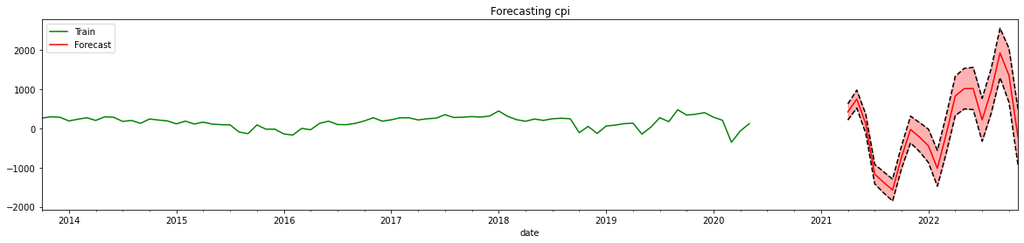

```python
lag_order = results.k_ar
# lag_order = 7
past_x = train[-lag_order:].values
n = test.shape[0]
forecast, lower, upper = results.forecast_interval(past_x, steps=n)

ax = train.iloc[:-lag_order, 1].plot(style='g', figsize=(20,4))
pred_forecast = pd.Series(forecast[:, 1], index=test.index).plot(style='r', ax=ax)
pred_lower = pd.Series(lower[:, 1], index=test.index).plot(style='k--', ax=ax)
pred_upper = pd.Series(upper[:, 1], index=test.index).plot(style='k--', ax=ax)
plt.fill_between(test.index, lower[:,1], upper[:,1], alpha=0.3, color='r')
plt.title('Forecasting cpi')
plt.legend(['Train','Forecast'])
plt.show()
```

### Evaluating Vector Autoregressive (VAR) Models

### Autocorrelation check - ACF and PACF plot on residuals

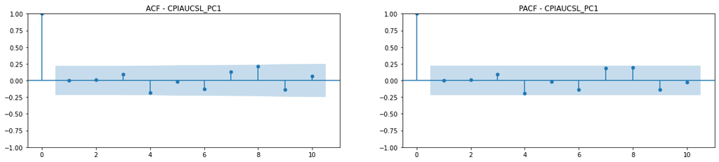

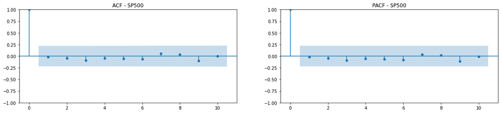

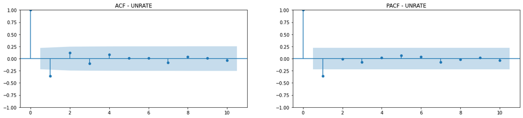

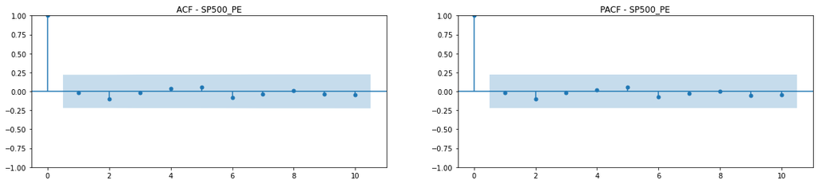

```python
from statsmodels.graphics.tsaplots import plot_acf, plot_pacf
for col in diffDF.columns:
    fig, ax = plt.subplots(1,2, figsize=(20,4))
    plot_acf(results.resid[col], zero=True, lags=10, ax=ax[0], title=f'ACF - {col}')
    plot_pacf(results.resid[col], zero=True, method='ywm', lags=10, ax=ax[1], title=f'PACF - {col}')
    plt.show()
```

### Using ljungbox

```python
from statsmodels.stats.diagnostic import acorr_ljungbox
for col in diffDF.columns:
    print(col, '\n', acorr_ljungbox(results.resid[col], lags=10)['lb_pvalue'])
```

```
CPIAUCSL_PC1
 1     0.987537
2     0.993354
3     0.859733
4     0.435374
5     0.577669
6     0.503276
7     0.436802
8     0.195095
9     0.172957
10    0.216935
Name: lb_pvalue, dtype: float64
SP500
 1     0.858171
2     0.915339
```

[output cut: 33 more lines]

#### 除了UNRATE前兩個p-values < 0.05，其他所有p-values > 0.05，沒辦法拒絕原假設( 𝐻𝑜 )，沒有自相關

```python
from sklearn.metrics import mean_absolute_percentage_error as mape
from sklearn.metrics import r2_score
import numpy as np

VAR_mape = np.round(mape(test['CPIAUCSL_PC1'], forecast[:, 1]), 4)
VAR_r2 = np.round(r2_score(test['CPIAUCSL_PC1'], forecast[:, 1]), 4)
print(f'MAPE: {VAR_mape} and R2 = {VAR_r2}')
```

```
MAPE: 804.9625 and R2 = -370240.94
```

#### 若用mape、r2評估會發現結果異常的差

返回目錄

### 3.Auto ARIMA Model

```python
diffDF.dropna(inplace=True)
```

```python
diffDF.info()
```

```
<class 'pandas.core.frame.DataFrame'>
DatetimeIndex: 110 entries, 2013-10-01 to 2022-11-01
Freq: MS
Data columns (total 4 columns):
 #   Column        Non-Null Count  Dtype
---  ------        --------------  -----
 0   CPIAUCSL_PC1  110 non-null    float64
 1   SP500         110 non-null    float64
 2   UNRATE        110 non-null    float64
 3   SP500_PE      110 non-null    float64
dtypes: float64(4)
memory usage: 4.3 KB
```

```python
diffDF = diffDF.asfreq('MS')
diffDF.info()
```

```
<class 'pandas.core.frame.DataFrame'>
DatetimeIndex: 110 entries, 2013-10-01 to 2022-11-01
Freq: MS
Data columns (total 4 columns):
 #   Column        Non-Null Count  Dtype
---  ------        --------------  -----
 0   CPIAUCSL_PC1  110 non-null    float64
 1   SP500         110 non-null    float64
 2   UNRATE        110 non-null    float64
 3   SP500_PE      110 non-null    float64
dtypes: float64(4)
memory usage: 4.3 KB
```

```python
target_train = target[:90]
feature_train = featureData[:90]
```

```python
from pmdarima.arima import auto_arima
auto_model = auto_arima(y=target_train, X=feature_train, seasonal=True, m=4, test='adf',
                        stepwise=True, trace=True) # m=4 for quarterly data
```

```
Performing stepwise search to minimize aic
 ARIMA(2,0,2)(1,0,1)[4] intercept   : AIC=87.893, Time=0.32 sec
 ARIMA(0,0,0)(0,0,0)[4] intercept   : AIC=225.844, Time=0.12 sec
 ARIMA(1,0,0)(1,0,0)[4] intercept   : AIC=108.776, Time=0.25 sec
 ARIMA(0,0,1)(0,0,1)[4] intercept   : AIC=118.774, Time=0.21 sec
 ARIMA(0,0,0)(0,0,0)[4]             : AIC=224.625, Time=0.08 sec
 ARIMA(2,0,2)(0,0,1)[4] intercept   : AIC=101.130, Time=0.31 sec
 ARIMA(2,0,2)(1,0,0)[4] intercept   : AIC=97.163, Time=0.28 sec
 ARIMA(2,0,2)(2,0,1)[4] intercept   : AIC=78.377, Time=0.44 sec
 ARIMA(2,0,2)(2,0,0)[4] intercept   : AIC=74.371, Time=0.38 sec
 ARIMA(1,0,2)(2,0,0)[4] intercept   : AIC=63.547, Time=0.33 sec
 ARIMA(1,0,2)(1,0,0)[4] intercept   : AIC=90.581, Time=0.25 sec
 ARIMA(1,0,2)(2,0,1)[4] intercept   : AIC=65.814, Time=0.39 sec
 ARIMA(1,0,2)(1,0,1)[4] intercept   : AIC=86.474, Time=0.30 sec
 ARIMA(0,0,2)(2,0,0)[4] intercept   : AIC=inf, Time=0.27 sec
 ARIMA(1,0,1)(2,0,0)[4] intercept   : AIC=61.461, Time=0.28 sec
 ARIMA(1,0,1)(1,0,0)[4] intercept   : AIC=92.956, Time=0.27 sec
 ARIMA(1,0,1)(2,0,1)[4] intercept   : AIC=64.788, Time=0.37 sec
 ARIMA(1,0,1)(1,0,1)[4] intercept   : AIC=87.406, Time=0.27 sec
 ARIMA(0,0,1)(2,0,0)[4] intercept   : AIC=111.960, Time=0.21 sec
 ARIMA(1,0,0)(2,0,0)[4] intercept   : AIC=80.421, Time=0.28 sec
 ARIMA(2,0,1)(2,0,0)[4] intercept   : AIC=63.025, Time=0.32 sec
 ARIMA(0,0,0)(2,0,0)[4] intercept   : AIC=197.148, Time=0.30 sec
 ARIMA(2,0,0)(2,0,0)[4] intercept   : AIC=62.992, Time=0.28 sec
 ARIMA(1,0,1)(2,0,0)[4]             : AIC=60.628, Time=0.25 sec
 ARIMA(1,0,1)(1,0,0)[4]             : AIC=90.957, Time=0.25 sec
 ARIMA(1,0,1)(2,0,1)[4]             : AIC=69.224, Time=0.35 sec
 ARIMA(1,0,1)(1,0,1)[4]             : AIC=85.317, Time=0.25 sec
 ARIMA(0,0,1)(2,0,0)[4]             : AIC=108.238, Time=0.19 sec
 ARIMA(1,0,0)(2,0,0)[4]             : AIC=76.368, Time=0.24 sec
 ARIMA(2,0,1)(2,0,0)[4]             : AIC=60.928, Time=0.28 sec
 ARIMA(1,0,2)(2,0,0)[4]             : AIC=61.911, Time=0.32 sec
 ARIMA(0,0,0)(2,0,0)[4]             : AIC=195.970, Time=0.14 sec
 ARIMA(0,0,2)(2,0,0)[4]             : AIC=inf, Time=0.22 sec
 ARIMA(2,0,0)(2,0,0)[4]             : AIC=66.818, Time=0.26 sec
 ARIMA(2,0,2)(2,0,0)[4]             : AIC=74.261, Time=0.31 sec

Best model:  ARIMA(1,0,1)(2,0,0)[4]
Total fit time: 9.602 seconds
```

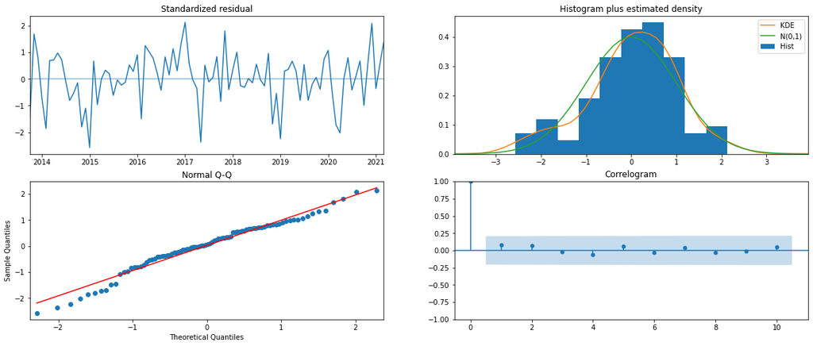

```python
auto_model.plot_diagnostics(figsize=(20,8))
plt.show()
```

#### 左下角的圖可發現大部分的都在線上，所以算還不錯

### Normality Test

```python
from scipy.stats import jarque_bera, shapiro
if jarque_bera(auto_model.resid())[1] > 0.05:
    print('p-value > 0.05，我們不能拒絕原假設(無法拒絕是常態分布的假設)。')
else:
    print('p-value < 0.05，我們拒絕原假設(拒絕是常態分布的假設)。')
```

```
p-value < 0.05，我們拒絕原假設(拒絕是常態分布的假設)。
```

### Testing for Autocorrelation Using acorr_ljungbox

```python
from statsmodels.stats.diagnostic import acorr_ljungbox
acorr_ljungbox(auto_model.resid(), lags=10)['lb_pvalue']
```

```
1     0.830658
2     0.959798
3     0.991826
4     0.998786
5     0.999120
6     0.999407
7     0.999871
8     0.999778
9     0.999943
10    0.999823
Name: lb_pvalue, dtype: float64
```

#### 所有p-values > 0.05，沒辦法拒絕原假設( 𝐻𝑜 )，沒有自相關

### Rolling Forecast Using SARIMAX

SARIMAX 模型通過添加外生變量（輸入變量）的影響擴展了 SARIMA(p,d,q)(P,D,Q)m 模型。 因此，我們可以將現值𝑦𝑡簡單地表示為 SARIMA(p,d,q)(P,D,Q)m 模型

```python
from sklearn.metrics import mean_absolute_percentage_error as mape
from sklearn.metrics import r2_score
```

```python
from statsmodels.tsa.statespace.sarimax import SARIMAX

target_train = target[:90]
target_test = target[90:]
train_len = len(target_train)
total_len = target.shape[0]
WINDOW = 1
pred_SARIMAX = []
for i in range(train_len, total_len, WINDOW):
    model = SARIMAX(target[:i], featureData[:i], order=(1,0,1), seasonal_order=(2,0,0,4))
    res = model.fit(disp=False)
    predictions = res.get_prediction(exog=featureData)
    oos_pred = predictions.predicted_mean.iloc[-WINDOW:]
    pred_SARIMAX.extend(oos_pred)
```

[output not shown]

```python
predDF = pd.DataFrame({'actual': target_test})
predDF['pred_SARIMAX'] = pred_SARIMAX
predDF.head(3).append(predDF.tail(3))
```

| date | actual | pred_SARIMAX |
| --- | --- | --- |
| 2021-04-01 | 2.82440 | 1.198419 |
| 2021-05-01 | 3.54379 | 2.161321 |
| 2021-06-01 | 4.15682 | 2.894307 |
| 2022-09-01 | 0.69648 | 1.219864 |
| 2022-10-01 | -0.14890 | 0.921881 |
| 2022-11-01 | -1.43971 | 0.330757 |

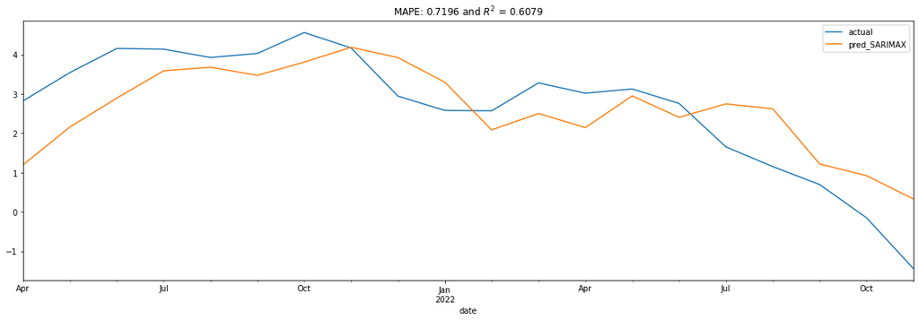

```python
import numpy as np

SARIMAX_mape_diff = np.round(mape(predDF.actual, predDF.pred_SARIMAX), 4)
SARIMAX_r2_diff = np.round(r2_score(predDF.actual, predDF.pred_SARIMAX), 4)
predDF.plot(figsize=(20,6), title = f'MAPE: {SARIMAX_mape_diff} and $R^2$ = {SARIMAX_r2_diff}')
plt.show()
```

#### 可以看到SARIMAX效果還不錯，是相當合適的模型

返回目錄

### 3.Prophet

```python
diffDF.head()
```

| date | CPIAUCSL_PC1 | SP500 | UNRATE | SP500_PE |
| --- | --- | --- | --- | --- |
| 2013-10-01 | -1.14134 | 258.43 | -0.3 | 0.17 |
| 2013-11-01 | -0.28588 | 291.13 | -0.4 | -0.10 |
| 2013-12-01 | 0.37403 | 279.17 | -0.5 | 0.24 |
| 2014-01-01 | 0.16737 | 185.02 | -0.6 | 0.03 |
| 2014-02-01 | -0.59532 | 228.71 | -0.5 | 0.15 |

```python
dataProphet = diffDF.reset_index()
```

```python
dataProphet.head()
```

|  | date | CPIAUCSL_PC1 | SP500 | UNRATE | SP500_PE |
| --- | --- | --- | --- | --- | --- |
| 0 | 2013-10-01 | -1.14134 | 258.43 | -0.3 | 0.17 |
| 1 | 2013-11-01 | -0.28588 | 291.13 | -0.4 | -0.10 |
| 2 | 2013-12-01 | 0.37403 | 279.17 | -0.5 | 0.24 |
| 3 | 2014-01-01 | 0.16737 | 185.02 | -0.6 | 0.03 |
| 4 | 2014-02-01 | -0.59532 | 228.71 | -0.5 | 0.15 |

```python
dataProphet.columns = ['ds', 'y', 'sp500', 'unrate', 'sp500_PE']
dataProphet.head(3)
```

|  | ds | y | sp500 | unrate | sp500_PE |
| --- | --- | --- | --- | --- | --- |
| 0 | 2013-10-01 | -1.14134 | 258.43 | -0.3 | 0.17 |
| 1 | 2013-11-01 | -0.28588 | 291.13 | -0.4 | -0.10 |
| 2 | 2013-12-01 | 0.37403 | 279.17 | -0.5 | 0.24 |

### Data Visualization

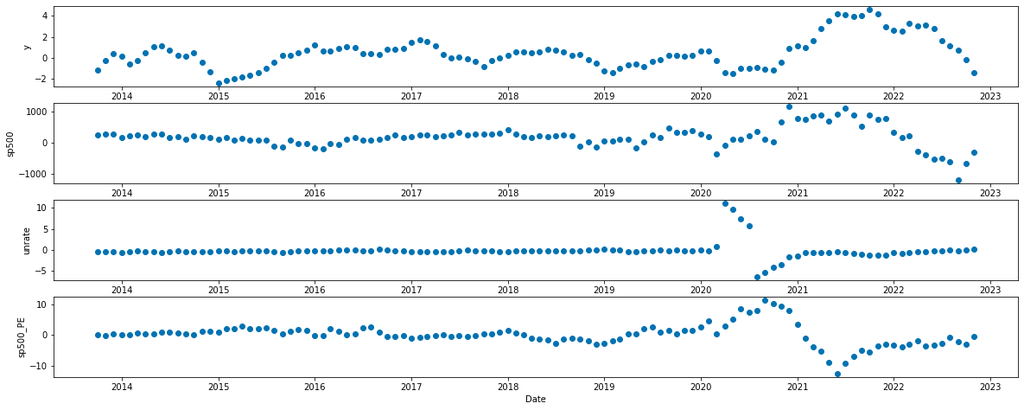

```python
fig = plt.figure(figsize=(20, 12))
for i, colname in zip(range(dataProphet.shape[1]-1), dataProphet.columns[1:]):
    figNo = 600+10+i+1
    fig.add_subplot(figNo)
    plt.scatter(pd.to_datetime(dataProphet['ds']), dataProphet[colname], c='#0072B2')
    plt.xlabel('Date')
    plt.ylabel(colname)
plt.show()
```

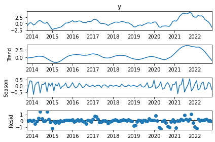

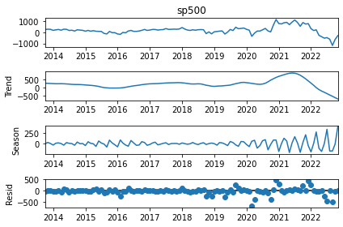

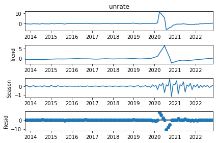

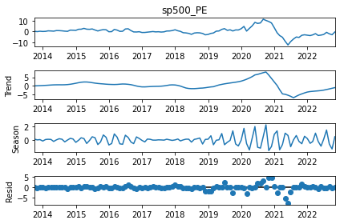

```python
from statsmodels.tsa.seasonal import STL
for i, colname in zip(range(dataProphet.shape[1]-1), dataProphet.columns[1:]):
    decomposition = STL(dataProphet.set_index('ds')[colname], period=4, robust=True).fit()
    plt.figure(figsize=(20,6))
    decomposition.plot();
    plt.show()
```

```python
def stationarity_test(data):
    for col in data.columns:
        if adfuller(data[col])[1] > 0.05:
            print(f'{col} p-value > 0.05，我們不能拒絕原假設(也就是說我們有一個非平穩的數據集)。')
        else:
            print(f'{col} p-value < 0.05，我們拒絕原假設(也就是說我們有一個平穩的數據集)。')
```

```python
dataProphet_no_ds = dataProphet.drop('ds',axis=1)
stationarity_test(dataProphet_no_ds)
```

```
y p-value < 0.05，我們拒絕原假設(也就是說我們有一個平穩的數據集)。
sp500 p-value < 0.05，我們拒絕原假設(也就是說我們有一個平穩的數據集)。
unrate p-value < 0.05，我們拒絕原假設(也就是說我們有一個平穩的數據集)。
sp500_PE p-value < 0.05，我們拒絕原假設(也就是說我們有一個平穩的數據集)。
```

### Quarterly's Yearly by Yearly Changes

```python
dataProphet_diff4 = dataProphet_no_ds.diff(4)
dataProphet_diff4['ds'] = dataProphet['ds']
dataProphet_diff4.insert(0, 'ds', dataProphet_diff4.pop('ds'))
dataProphet_diff4.head(3)
```

|  | ds | y | sp500 | unrate | sp500_PE |
| --- | --- | --- | --- | --- | --- |
| 0 | 2013-10-01 | NaN | NaN | NaN | NaN |
| 1 | 2013-11-01 | NaN | NaN | NaN | NaN |
| 2 | 2013-12-01 | NaN | NaN | NaN | NaN |

```python
dataProphet_diff4.dropna(inplace=True)
dataProphet_diff4=dataProphet_diff4.reset_index(drop=True)
stationarity_test(dataProphet_diff4)
```

```
ds p-value > 0.05，我們不能拒絕原假設(也就是說我們有一個非平穩的數據集)。
y p-value > 0.05，我們不能拒絕原假設(也就是說我們有一個非平穩的數據集)。
sp500 p-value > 0.05，我們不能拒絕原假設(也就是說我們有一個非平穩的數據集)。
unrate p-value < 0.05，我們拒絕原假設(也就是說我們有一個平穩的數據集)。
sp500_PE p-value > 0.05，我們不能拒絕原假設(也就是說我們有一個非平穩的數據集)。
```

```python
dataProphet_diff4.head(2)
```

|  | ds | y | sp500 | unrate | sp500_PE |
| --- | --- | --- | --- | --- | --- |
| 0 | 2014-02-01 | 0.54602 | -29.72 | -0.2 | -0.02 |
| 1 | 2014-03-01 | 0.01310 | -25.07 | 0.2 | 0.70 |

```python
dataProphet.head(2)
```

|  | ds | y | sp500 | unrate | sp500_PE |
| --- | --- | --- | --- | --- | --- |
| 0 | 2013-10-01 | -1.14134 | 258.43 | -0.3 | 0.17 |
| 1 | 2013-11-01 | -0.28588 | 291.13 | -0.4 | -0.10 |

```python
from prophet import Prophet
from prophet.utilities import regressor_coefficients
import seaborn as sns

def prophet_modeling(seasonality_mode, train, test, dataProphet, FREQ="MS"):
    m = Prophet(daily_seasonality = True, seasonality_mode=seasonality_mode)
    m.add_regressor('sp500')
    m.add_regressor('unrate')
    m.fit(train)
    # Forecast Future
    future = m.make_future_dataframe(periods=test.shape[0], freq = FREQ, include_history=True)
    future['sp500'] = dataProphet['sp500']
    future['unrate'] = dataProphet['unrate']

    # prediction = m.predict(future.dropna()
    prediction = m.predict(future)

    # Plot all
    m.plot(prediction, figsize=(20, 4))
    plt.title(f"Prediction of the Future CPI for the next {test.shape[0]} steps ({FREQ})")
    plt.xlabel("Date")
    plt.ylabel("CPI")
    plt.show()

    # plot on test data
    prediction['y'] = dataProphet['y']
    prediction['Date'] = dataProphet['ds']
    prediction= prediction.set_index('Date')

    fig, ax = plt.subplots(figsize=(20,4))
    testDF = prediction[['y', 'yhat_lower', 'yhat_upper', 'yhat']][90:]
    Prophet_mape = np.round(mape(testDF.y, testDF.yhat), 4)
    Prophet_r2 = np.round(r2_score(testDF.y, testDF.yhat), 4)

    ax = sns.lineplot(data=testDF)
    ax.fill_between(testDF.index, testDF.yhat_lower, testDF.yhat_upper, alpha=0.3)
    ax.set(title= f' CPI Forecase - actual vs. predicted; Test MAPE: {Prophet_mape}; '+\
           f'Test $R^2$: {Prophet_r2}', xlabel='Date', ylabel='CPI')
    plt.show()
    # side_by_side('SARIMAX MAPE: ', SARIMAX_mape, 'Prophet MAPE: ', Prophet_mape)
    # print(regressor_coefficients(m))
    return m, Prophet_mape, Prophet_r2
```

### dataProphet_diff

```
19:33:39 - cmdstanpy - INFO - Chain [1] start processing
19:33:40 - cmdstanpy - INFO - Chain [1] done processing
```

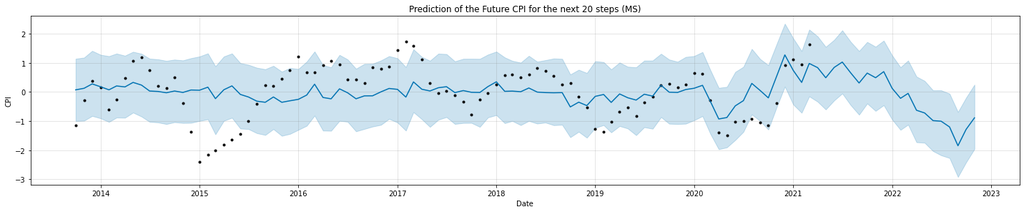

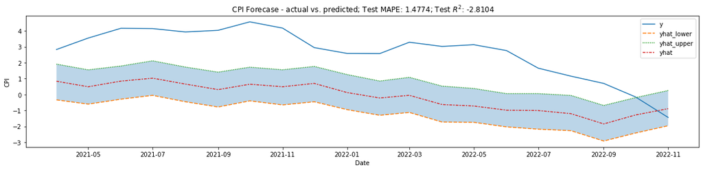

```python
m, Prophet_mape_diff, Prophet_r2_diff = prophet_modeling('additive', dataProphet[:90],
                                               dataProphet[90:], dataProphet, FREQ="MS")
```

```python
regressor_coefficients(m)
```

|  | regressor | regressor_mode | center | coef_lower | coef | coef_upper |
| --- | --- | --- | --- | --- | --- | --- |
| 0 | sp500 | additive | 198.483889 | 0.001200 | 0.001200 | 0.001200 |
| 1 | unrate | additive | -0.043333 | -0.053111 | -0.053111 | -0.053111 |

### dataProphet_diff4

```
19:33:40 - cmdstanpy - INFO - Chain [1] start processing
19:33:41 - cmdstanpy - INFO - Chain [1] done processing
```

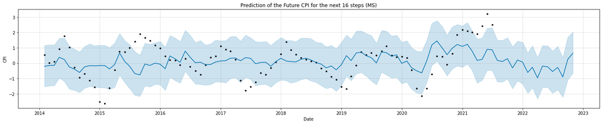

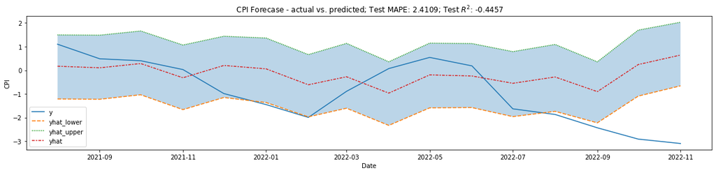

|  | regressor | regressor_mode | center | coef_lower | coef | coef_upper |
| --- | --- | --- | --- | --- | --- | --- |
| 0 | sp500 | additive | 29.554444 | 0.001418 | 0.001418 | 0.001418 |
| 1 | unrate | additive | -0.004444 | -0.040530 | -0.040530 | -0.040530 |

```python
m, Prophet_mape_diff4, Prophet_r2_diff4 = prophet_modeling('additive', dataProphet_diff4[:90],
                                                         dataProphet_diff4[90:], dataProphet_diff4, FREQ="MS")
regressor_coefficients(m)
```

### Performance Comparison of SARIMAX and Prophet (SARIMAX和Prophet的性能對比)

```python
measures = [[SARIMAX_mape_diff, SARIMAX_r2_diff],
            [Prophet_mape_diff, Prophet_r2_diff],
            [Prophet_mape_diff4, Prophet_r2_diff4]]

metricsDF = pd.DataFrame(data = measures,
                         columns= ['MAPE', 'Test R2'],
                         index = ['SARIMAX_diff',
                                  'Prophete_diff', 'Prophet_diff4'])
metricsDF
```

|  | MAPE | Test R2 |
| --- | --- | --- |
| SARIMAX_diff | 0.7196 | 0.6079 |
| Prophete_diff | 1.4774 | -2.8104 |
| Prophet_diff4 | 2.4109 | -0.4457 |

#### 可以發現MAPE最小的為SARIMAX，Test R2最大的也是SARIMAX，因此SARIMAX模型與prophet相較之下反而會是較好的

返回目錄

### 5.Machine Learning - Linear and Nonlinear Regression Models (機器學習 - 線性和非線性回歸模型)

### Linear Regression Models (線性回歸模型)

```python
from sklearn.preprocessing import PolynomialFeatures, StandardScaler, normalize
from sklearn.linear_model import Lasso, Ridge, LinearRegression, SGDRegressor, ARDRegression, Perceptron
from sklearn.svm import SVR
from sklearn.neural_network import MLPRegressor
import statsmodels.api as sm
import numpy as np
```

```python
from datetime import datetime
skLR = LinearRegression(fit_intercept=True)
polyReg = LinearRegression(fit_intercept=True) #normalize=True,
ridge = Ridge(alpha=1, solver='sag', random_state=42)
lasso = Lasso(alpha=0.01, random_state=42)
SGD = SGDRegressor(max_iter=5000, eta0=0.00001, power_t=0.15, shuffle = False)
ARD = ARDRegression()
svr_linear = SVR(kernel="linear", C=1000)
# Nonlinear Regressor
regrNN = MLPRegressor(hidden_layer_sizes=(200, 100, 50, 25), activation = 'relu', shuffle = False,
                      alpha=0.0001, random_state=1, max_iter=50000)
svr_nonlinear = SVR(kernel="rbf", C=1000)
```

```python
def train_test_process(listModels, listModelNames, trainData, testData, trainTarget, testTarget):
    print("模型訓練與測試\n")
    modelOLS = sm.OLS(trainTarget, trainData) # The benchmark model
    OLS_fit = modelOLS.fit()
    summary = OLS_fit.summary2()
    print("statsmodels OLS R^2 (Training Data Only) = ", summary.tables[0][0][6], summary.tables[0][1][6])
    prediction = OLS_fit.predict(testData)
    print("statsmodels OLS R^2 (Testing Data Only) = ", r2_score(testTarget, prediction))

    nameList = ['Ordinary Least Squares (OLS)']
    scoreList_Train=[float(summary.tables[0][1][6])]
    scoreList_Test=[r2_score(testTarget, prediction)]
    for aModel, aModelName in zip(listModels, listModelNames):
        process_starttime = datetime.now()
        if aModelName == 'Polynomial Regressor':
            poly = PolynomialFeatures(degree=2, include_bias=False)
            poly_features_train = poly.fit_transform(trainData)
            poly_features_test = poly.fit_transform(testData)
            aModel.fit(poly_features_train, trainTarget)
            y_hat = aModel.predict(poly_features_test)
            print ("\n..... "+aModelName+" 模型訓練花費時間 %s" % (datetime.now() - process_starttime))
            score_r2_train = aModel.score(poly_features_train, trainTarget).round(4)
            score_r2_test = aModel.score(poly_features_test,  testTarget).round(4)
        else:
            aModel.fit(trainData, trainTarget)
            y_hat = aModel.predict(testData)
            print ("\n..... "+aModelName+" 模型訓練花費時間 %s" % (datetime.now() - process_starttime))
            score_r2_train = aModel.score(trainData, trainTarget).round(4)
            score_r2_test = aModel.score(testData,  testTarget).round(4)
        nameList.append(aModelName)
        scoreList_Train.append(score_r2_train)
        scoreList_Test.append(score_r2_test)
    resultDF = pd.DataFrame(data = list(zip(nameList, scoreList_Train, scoreList_Test)),
                            columns=['Name of Regressor', 'Training r2', 'Testing r2'])
    resultDF.sort_values("Training r2", axis = 0, ascending = False, inplace = True)
    resultDF.reset_index(drop=True,  inplace = True)
    resultDF['Diff%'] = np.round((resultDF['Training r2']-resultDF['Testing r2'])/resultDF['Training r2'],
                                 4)*100
    return resultDF
```

```python
listModelNames = ['Linear Regressor', 'Polynomial Regressor', 'Ridge Regressor', 'Lasso Regressor',
                  'SGD', ' Bayesian ARD regression', 'Support Vector Linear Regressor',
                  'Support Vector Nonlinear Regressor', 'Neural Nework Regressor']
listModels = [skLR, polyReg, ridge, lasso, SGD, ARD, svr_linear, svr_nonlinear, regrNN]
```

### diff

```python
target_train = target[:90]
feature_train = featureData[:90]
target_test = target[90:]
feature_test = featureData[90:]
resultDF = train_test_process(listModels, listModelNames, feature_train, feature_test,
                              target_train, target_test)
resultDF
```

```
模型訓練與測試

statsmodels OLS R^2 (Training Data Only) =  R-squared (uncentered): 0.225
statsmodels OLS R^2 (Testing Data Only) =  -0.8838004298611843

..... Linear Regressor 模型訓練花費時間 0:00:00.001994

..... Polynomial Regressor 模型訓練花費時間 0:00:00.003989

..... Ridge Regressor 模型訓練花費時間 0:00:00.007979

..... Lasso Regressor 模型訓練花費時間 0:00:00.003990

..... SGD 模型訓練花費時間 0:00:00.001995

.....  Bayesian ARD regression 模型訓練花費時間 0:00:00.011967
```

```
..... Support Vector Linear Regressor 模型訓練花費時間 0:01:21.959757

..... Support Vector Nonlinear Regressor 模型訓練花費時間 0:00:00.004986

..... Neural Nework Regressor 模型訓練花費時間 0:00:00.307699
```

|  | Name of Regressor | Training r2 | Testing r2 | Diff% |
| --- | --- | --- | --- | --- |
| 0 | Support Vector Nonlinear Regressor | 0.3609 | -3.5194 | 1075.17 |
| 1 | Neural Nework Regressor | 0.3448 | -1.3441 | 489.82 |
| 2 | Polynomial Regressor | 0.2586 | -0.3807 | 247.22 |
| 3 | Linear Regressor | 0.2316 | -1.0168 | 539.03 |
| 4 | Lasso Regressor | 0.2316 | -1.0313 | 545.29 |
| 5 | Ordinary Least Squares (OLS) | 0.2250 | -0.8838 | 492.80 |
| 6 | Ridge Regressor | 0.1906 | -1.7013 | 992.60 |
| 7 | Bayesian ARD regression | 0.1466 | -1.5768 | 1175.58 |
| 8 | SGD | 0.0055 | -3.0133 | 54887.27 |
| 9 | Support Vector Linear Regressor | -4.6990 | -3.1800 | 32.33 |

#### 使用線性回歸模型發現訓練r2皆沒有達到0.5，測試更是差，因此完全不適合使用線性回歸

### 非線性回歸的決策樹與集成學習模組

```python
from sklearn.tree import DecisionTreeRegressor
from sklearn.ensemble import AdaBoostRegressor
from sklearn.ensemble import GradientBoostingRegressor
from sklearn.ensemble import RandomForestRegressor
from sklearn.linear_model import LinearRegression
from sklearn.ensemble import VotingRegressor
```

```python
dtr = DecisionTreeRegressor(max_depth=4)
abr = AdaBoostRegressor(DecisionTreeRegressor(max_depth=4), n_estimators=300, random_state=22)
gbr = GradientBoostingRegressor(random_state=1)
rfr = RandomForestRegressor(n_estimators=10, random_state=1)
lr = LinearRegression()
er = VotingRegressor([('dtr', dtr), ('abr', abr), ('gbr', gbr), ('rfr', rfr), ('lr', lr)])
```

```python
listModelNames = ['Decision Tree Regress', 'AdaBoost Regressor', 'Gradient Boosting Regressor',
                  'Random Forest Regressor', 'Linear Regression Regressor', 'Voting Regressor']
listModels = [dtr, abr, gbr, rfr, lr, er]
```

### diff

```python
result_ensembleDF = train_test_process(listModels, listModelNames, feature_train, feature_test,
                                       target_train, target_test)
result_ensembleDF
```

```
模型訓練與測試

statsmodels OLS R^2 (Training Data Only) =  R-squared (uncentered): 0.225
statsmodels OLS R^2 (Testing Data Only) =  -0.8838004298611843

..... Decision Tree Regress 模型訓練花費時間 0:00:00.005985

..... AdaBoost Regressor 模型訓練花費時間 0:00:00.301191

..... Gradient Boosting Regressor 模型訓練花費時間 0:00:00.041887

..... Random Forest Regressor 模型訓練花費時間 0:00:00.012966

..... Linear Regression Regressor 模型訓練花費時間 0:00:00.001995

..... Voting Regressor 模型訓練花費時間 0:00:00.370007
```

|  | Name of Regressor | Training r2 | Testing r2 | Diff% |
| --- | --- | --- | --- | --- |
| 0 | Gradient Boosting Regressor | 0.9287 | -1.0164 | 209.44 |
| 1 | AdaBoost Regressor | 0.8598 | -1.2885 | 249.86 |
| 2 | Random Forest Regressor | 0.8445 | -1.4571 | 272.54 |
| 3 | Voting Regressor | 0.8155 | -1.0960 | 234.40 |
| 4 | Decision Tree Regress | 0.7139 | -0.9379 | 231.38 |
| 5 | Linear Regression Regressor | 0.2316 | -1.0168 | 539.03 |
| 6 | Ordinary Least Squares (OLS) | 0.2250 | -0.8838 | 492.80 |

#### 在非線性回歸中，訓練效果皆不錯，但測試也一樣不佳，可能是因為測試資料是拿疫情後的資料來做測試不太合適。

#### 因此把訓練資料減少，測試資料拉長一點看看效果

```python
length = 55
target_train = target[:length]
feature_train = featureData[:length]
target_test = target[length:]
feature_test = featureData[length:]
result_ensemble_diffDF = train_test_process(listModels, listModelNames, feature_train,
                                            feature_test, target_train, target_test)
result_ensemble_diffDF
```

```
模型訓練與測試

statsmodels OLS R^2 (Training Data Only) =  R-squared (uncentered): 0.208
statsmodels OLS R^2 (Testing Data Only) =  -0.4525928555292391

..... Decision Tree Regress 模型訓練花費時間 0:00:00.001994

..... AdaBoost Regressor 模型訓練花費時間 0:00:00.304185

..... Gradient Boosting Regressor 模型訓練花費時間 0:00:00.038896

..... Random Forest Regressor 模型訓練花費時間 0:00:00.011968

..... Linear Regression Regressor 模型訓練花費時間 0:00:00.000997

..... Voting Regressor 模型訓練花費時間 0:00:00.337095
```

|  | Name of Regressor | Training r2 | Testing r2 | Diff% |
| --- | --- | --- | --- | --- |
| 0 | Gradient Boosting Regressor | 0.9847 | 0.118900 | 87.93 |
| 1 | AdaBoost Regressor | 0.9317 | 0.164700 | 82.32 |
| 2 | Random Forest Regressor | 0.8849 | 0.203000 | 77.06 |
| 3 | Voting Regressor | 0.8713 | 0.254500 | 70.79 |
| 4 | Decision Tree Regress | 0.7404 | 0.330400 | 55.38 |
| 5 | Linear Regression Regressor | 0.3224 | -1.057700 | 428.07 |
| 6 | Ordinary Least Squares (OLS) | 0.2080 | -0.452593 | 317.59 |

#### 將測試資料拉長後(拿一半的資料)，大多數測試的r square有變成正的。

#### 例如Decision Tree Regress的訓練r square是可接受的，測試的r square是最好的，但還不夠好。其他方法如Voting Regressor、Random Forest Regressor也有勉強合理的成果

### Residuald Plot Using yellowbrick

```python
dtr = DecisionTreeRegressor(max_depth=4)
```

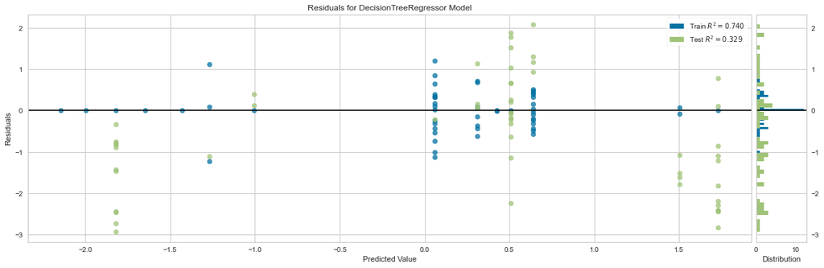

```python
from yellowbrick.regressor import ResidualsPlot
plt.subplots(figsize=(20,6))
# Create training and test sets
visualizer = ResidualsPlot(dtr)
visualizer.fit(feature_train, target_train)
visualizer.score(feature_test, target_test)
visualizer.show();
```

返回目錄

### 6.Conclusion

比較了VAR model、SARIMAX、Prophet、Machine Learning這些方法

在這次的實驗中我們發現到SARIMAX有較佳的模型，它在預測有測試結果有較好的match，其中MAPE是0.7196與R^2是0.6079；其次是當訓練資料與測試資料使用各半Decision Tree與少數非線性回歸的模型是勉強可以使用的。

而線性回歸所有方法皆不佳、Prophet效果也是異常的差，再來是VAR model是在這之中結果最糟糕的模型。

返回目錄